# OpenCaseStudies - Opoids

## t-test

http://www.sthda.com/english/wiki/unpaired-two-samples-t-test-in-r

```r
res1 <- t.test(DOSAGE_UNIT ~ UB14, data = dfAnnual, var.equal = TRUE)
res1
```

```
##
##  Two Sample t-test
##
## data:  DOSAGE_UNIT by UB14
## t = -80.001, df = 26978, p-value < 2.2e-16
## alternative hypothesis: true difference in means is not equal to 0
## 95 percent confidence interval:
##  -8777381 -8357569
## sample estimates:
## mean in group R mean in group U
##          833128         9400603
```

In the result above :

1. t is the t-test statistic value (t = -80.001),
2. df is the degrees of freedom (df= 26978),
3. p-value is the significance level of the t-test (p-value = 2.2e-16).
4. conf.int is the confidence interval of the mean at 95% (conf.int = [-8777381, -8357569]);
5. sample estimates is he mean value of the sample (mean = 833128, 9400603).

# EDA

## Across year

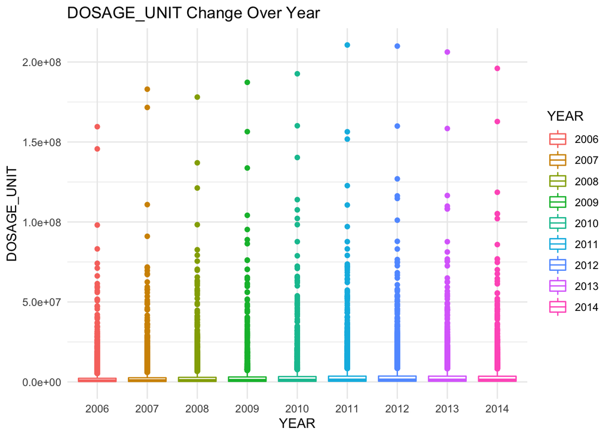

```r
ggplot(dfAnnual , aes(x = YEAR, y = DOSAGE_UNIT, colour = YEAR)) +
  geom_boxplot()+
  labs(title = "DOSAGE_UNIT Change Over Year")+
  theme_minimal()
```

We need normalization since the trend is not obvious. From the plot we can see without normalization, data are squished.

```r
StatePlot <- function(DF, title_str){

  p <- ggplot(DF, aes(x = YEAR, y = mean_DOSAGE, color = STATE)) +
  geom_line_interactive(aes(group= STATE,
  data_id = abbr2state(STATE), tooltip = abbr2state(STATE) ),
  show.legend = FALSE)+
  labs(title = title_str)+
  theme_minimal()

  girafe(code = print(p) )

}

D1 <- dfAnnual  %>% group_by(STATE,YEAR) %>%
     summarise( mean_DOSAGE = mean(DOSAGE_UNIT))


StatePlot(D1, "Mean Dosage Across without Normalization")
```

[interactive chart not shown]

California has larger prescription pain pills than others while North Dakota has the lowest. We will compare the results after doing normalization in later part.

## Normalization

```r
df <- dfAnnual %>% filter(YEAR %in% c('2010', '2011', '2012', '2013', '2014'))

df_dens <- df %>% mutate( dens_DOSAGE = case_when(
   YEAR=='2010' ~ DOSAGE_UNIT/ DENS10,
   YEAR=='2011' ~ DOSAGE_UNIT/ DENS11,
   YEAR=='2012' ~ DOSAGE_UNIT/ DENS12,
   YEAR=='2013' ~ DOSAGE_UNIT/ DENS13,
   YEAR=='2014' ~ DOSAGE_UNIT/ DENS14))

MinMax <- function(x){
  (x-min(x))/(max(x)-min(x)) }

df_gp <- rbind(subset(df, YEAR =='2010') %>% group_by(UB10) %>%
  mutate(gp_DOSAGE = MinMax(DOSAGE_UNIT) ),
subset(df, YEAR =='2011') %>% group_by(UB11) %>%
  mutate(gp_DOSAGE = MinMax(DOSAGE_UNIT) ),
subset(df, YEAR =='2012')  %>% group_by(UB12) %>%
  mutate( gp_DOSAGE = MinMax(DOSAGE_UNIT)) ,
subset(df, YEAR =='2013')  %>% group_by(UB13) %>%
  mutate( gp_DOSAGE = MinMax(DOSAGE_UNIT) ),
subset(df, YEAR =='2014')  %>% group_by(UB14) %>%
  mutate( gp_DOSAGE = MinMax(DOSAGE_UNIT) ) )
```

Why Density Normalization?

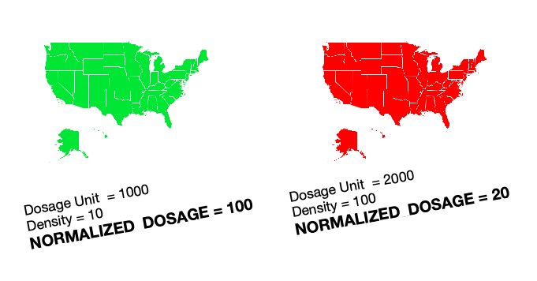

Min-max normalization, (usually called feature scaling) performs a linear transformation on the original data. This technique gets all the scaled data in the range [0,1]. The formula to achieve this is the following:
$$z = \frac{x-min(x)}{max(x)-min(x)}$$
Min-max normalization preserves the relationships among the original data values. The cost of having this bounded range is that we will end up with smaller standard deviations, which can suppress the effect of outliers. The reason I use `group_by` to preprocess is that I would like to show the difference between the use of dosuage in rural and urban more clearly, which preserves some properties. Here I am not intend to transform the target variable’s range but to highlight the importance of classification.

The mean of the series should not be a function of time rather should be a constant. Box plot across yeras will give us a sense on annual trend.

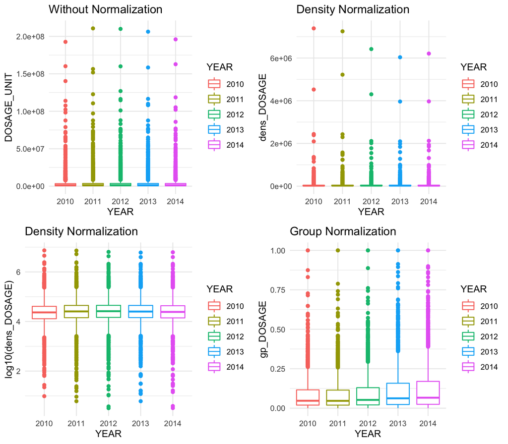

```r
p1 <- ggplot(df , aes(x = YEAR, y = DOSAGE_UNIT, colour = YEAR)) +
  geom_boxplot()+
  labs(title = "Without Normalization")+
  theme_minimal()


p2 <- ggplot(df_dens, aes(x = YEAR, y = dens_DOSAGE, colour = YEAR)) +
  geom_boxplot()+
  labs(title = "Density Normalization")+
  theme_minimal()


p3 <- ggplot(df_dens, aes(x = YEAR, y = log10(dens_DOSAGE), colour = YEAR)) +
  geom_boxplot()+
  labs(title = "Density Normalization")+
  theme_minimal()


p4 <- ggplot(df_gp, aes(x = YEAR, y = gp_DOSAGE, colour = YEAR)) +
  geom_boxplot()+
  labs(title = "Group Normalization")+
  theme_minimal()

ggarrange(p1, p2, p3,p4, nrow = 2, ncol=2)
```

## How rural and urban areas differ for prescription rates.

The goal of normalization is to make every datapoint have the same scale so each feature is equally important.

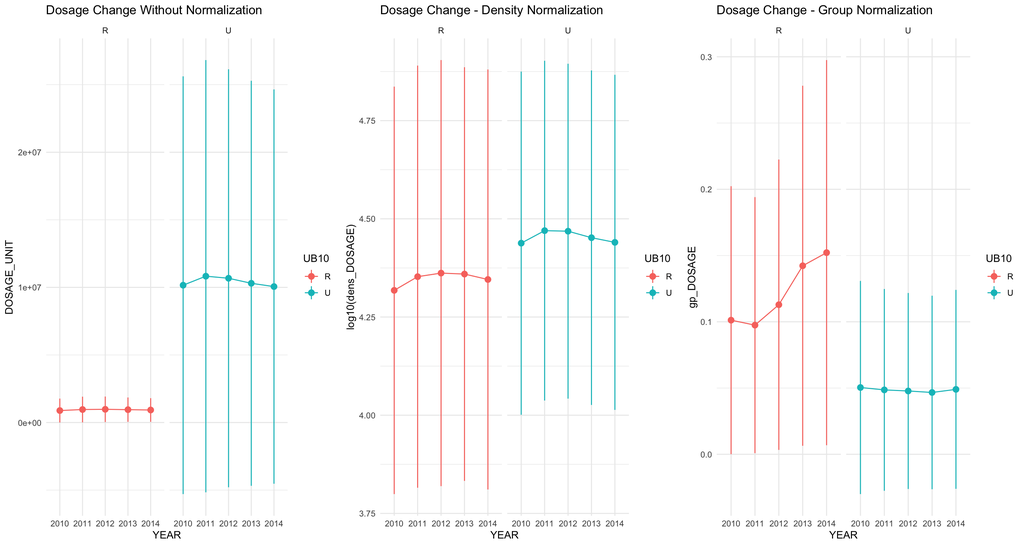

```r
p5 <- ggplot(df, aes(y = DOSAGE_UNIT, x = YEAR, colour = UB10, group = UB10)) +
  stat_summary(fun.y = mean,
               fun.ymin = function(x) mean(x) - sd(x),
               fun.ymax = function(x) mean(x) + sd(x),
               geom = "pointrange") +
  stat_summary(fun.y = mean,
               geom = "line") +
  facet_wrap( ~ UB10) +
  labs(title = "Dosage Change Without Normalization")+
  theme_minimal()

p6 <- ggplot(df_dens , aes(y = log10(dens_DOSAGE), x = YEAR, colour = UB10, group = UB10)) +
  stat_summary(fun.y = mean,
               fun.ymin = function(x) mean(x) - sd(x),
               fun.ymax = function(x) mean(x) + sd(x),
               geom = "pointrange") +
  stat_summary(fun.y = mean,
               geom = "line") +
  facet_wrap( ~  UB10) +
  labs(title = "Dosage Change - Density Normalization")+
  theme_minimal()

p7 <- ggplot(df_gp , aes(y = gp_DOSAGE, x = YEAR, colour = UB10, group = UB10)) +
  stat_summary(fun.y = mean,
               fun.ymin = function(x) mean(x) - sd(x),
               fun.ymax = function(x) mean(x) + sd(x),
               geom = "pointrange") +
  stat_summary(fun.y = mean,
               geom = "line") +
  facet_wrap( ~  UB10) +
  labs(title = "Dosage Change - Group Normalization")+
  theme_minimal()


ggarrange(p5, p6, p7,ncol=3 )
```

The left plot further indicates the importance of normalization. In the left plot, mean of dosage in rural area shows a minor change, and it is worth mentioning that its original range is also smaller than that of urban. Now one question arises in our mind: Is this slight change caused by its original narrow range? Move to the middle plot, we notice density normalization can stretch the range of rural to the same level as that of urban. The right plot, the one with group normalization, the rural area indicates larger consumption, which is totally different from the left one.

Which plot could better show the difference between the prescription rates of rural and urban area? After checking relevant reports, we find one analysis of patient opioid prescription data from a national electronic health record vendor found that the percentage of patients prescribed an opioid was higher in rural than in urban areas. It is because larger amount of dosage use in rural area might be attributed in part to prescription drug use and misuse at an earlier age as well as higher prevalences of chronic pain among persons living in rural areas.

## LMER

https://www.rensvandeschoot.com/tutorials/lme4/

multilevel regression

```r
l1 <- lmer(dens_DOSAGE ~ 1 + (1|YEAR), data = df_dens)
summary(l1)
```

```
## Linear mixed model fit by REML ['lmerMod']
## Formula: dens_DOSAGE ~ 1 + (1 | YEAR)
##    Data: df_dens
##
## REML criterion at convergence: 405106.6
##
## Scaled residuals:
##    Min     1Q Median     3Q    Max
## -0.278 -0.199 -0.138 -0.032 41.220
##
## Random effects:
##  Groups   Name        Variance  Std.Dev.
##  YEAR     (Intercept) 0.000e+00      0
##  Residual             3.169e+10 178028
## Number of obs: 14995, groups:  YEAR, 5
##
## Fixed effects:
##             Estimate Std. Error t value
## (Intercept)    49466       1454   34.02
## convergence code: 0
## boundary (singular) fit: see ?isSingular
```

```r
l2 <- lmer(dens_DOSAGE ~ 1 + (1|UB14), data = df_dens)
summary(l2)
```

```
## Linear mixed model fit by REML ['lmerMod']
## Formula: dens_DOSAGE ~ 1 + (1 | UB14)
##    Data: df_dens
##
## REML criterion at convergence: 405080.6
##
## Scaled residuals:
##    Min     1Q Median     3Q    Max
## -0.339 -0.201 -0.134 -0.027 41.198
##
## Random effects:
##  Groups   Name        Variance  Std.Dev.
##  UB14     (Intercept) 1.413e+08  11887
##  Residual             3.163e+10 177854
## Number of obs: 14995, groups:  UB14, 2
##
## Fixed effects:
##             Estimate Std. Error t value
## (Intercept)    52324       8546   6.123
```

## Across State with Normalizaiton

```r
D2 <- df_dens  %>% group_by(STATE,YEAR) %>%
     summarise( mean_DOSAGE = mean(dens_DOSAGE))


D3 <- df_gp  %>% group_by(STATE,YEAR) %>%
     summarise( mean_DOSAGE = mean(gp_DOSAGE))

StatePlot(D1, "Mean Dosage Across without Normalization")
```

[interactive chart not shown]

```r
StatePlot(D2, "Mean Dosage Across without Density Normalization")
```

[interactive chart not shown]

```r
StatePlot(D3, "Mean Dosage Across without Group Min-Max Normalization")
```

[interactive chart not shown]

The line graph presents the changing trends in the pills consumption in all states in United State between 2010 and 2014. Based on `df_dens`, the state with the highest pills consumption changes to Florida and the state with the lowest pills consumption is District of Columbia. It is evident that all states experienced a minor fluctuaion during this period.

Considering the plot generated by `df_gp`, Tennessee and North Dakota now are states with the highest and the lowest cosumption of pills respectively. To understand the trends more clearly, the next step is to monthly time series analysis on state level. Here, we choose state California, Florida and Tennessee as the representative.

# Monthly Time Series Analysis on State Level

```r
getMonthDrug <- function(s){
  data = summarized_county_monthly(state = s, key = "WaPo")  %>%
    filter(year %in% c('2010', '2011', '2012', '2013', '2014'))  %>%
  group_by(year, month) %>%
  summarise( state_Dosage = sum(DOSAGE_UNIT) )%>%
  mutate(date = as.Date(paste(year, as.character(month),'01',sep='-') ),
         STATE = abbr2state(s) ) #%>% select(id, STATE,mean_Dosage)
}


ca <- getMonthDrug('CA')
fl <- getMonthDrug('FL')
tn <- getMonthDrug('TN')
#nd <- getMonthDrug('ND')
#dc <- getMonthDrug('DC')
dfState <- rbind(ca,fl,tn)
```

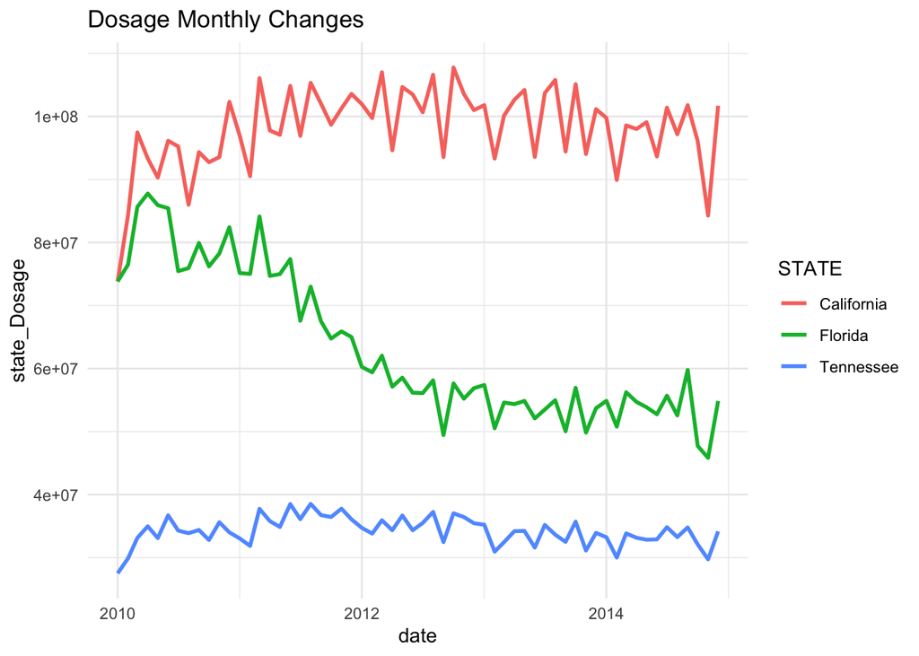

```r
ggplot(dfState , aes(x = date, y = state_Dosage)) +
  geom_line(aes(color = STATE,group = STATE), size = 1) +
  theme_minimal()+
  scale_x_date(date_labels = "%Y")+
  labs(title = "Dosage Monthly Changes")
```

To normalize, we search the population density of California, Florida and Tennessee are 251.3, 353.4 and 158.8 respectively.

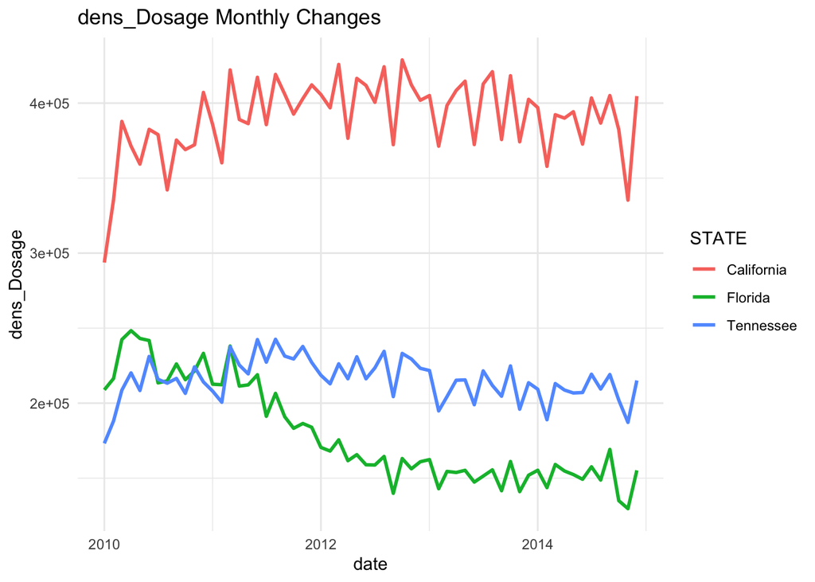

```r
dfState2 <- dfState %>% mutate( dens_Dosage = case_when(
   STATE =='California' ~ state_Dosage/ 251.3,
   STATE =='Florida' ~ state_Dosage/353.4 ,
   STATE =='Tennessee' ~ state_Dosage/158.8)) %>%
  select(date, STATE, dens_Dosage)


ggplot(dfState2, aes(x = date, y = dens_Dosage)) +
  geom_line(aes(color = STATE,group = STATE), size = 1) +
  theme_minimal()+
  scale_x_date(date_labels = "%Y")+
  labs(title = "dens_Dosage Monthly Changes")
```

For Florida, there is a general downward trend.

## Seasonal Decomposition

The `stl()` function is quite flexible:

- The seasonality does not have to run across a year. Any period may be used for this.
- The decomposition process can accommodate seasonality that changes over time.
- A robust decomposition process is available that is less affected by outliers than is the default.

```r
ts_analysis <- function(s){
  # Transform to `ts` class
  # Specify start and end year, measurement frequency (monthly = 12)
  s_ts <- ts(dfState2[dfState2$STATE== s, 'dens_Dosage'],start = 2010, end = 2014, freq = 12)
  # Decompose using `stl()`
  s_stl <- stl(s_ts, s.window = "period")
  # Generate plots
  plot(s_stl)  # top=original data, second=estimated seasonal, third=estimated smooth trend, bottom=estimated irregular element i.e. unaccounted for variation
  #monthplot(s_ts, choice = "seasonal")  # variation in dosage for each month
}
```

When calling `stl()` with `s.window='period'`, the seasonal component for January is simply the mean of all January values. Similarly, the seasonal component for February is simply the mean of all February values.

Having calculated the seasonal component, the seasonally-adjusted data (original data - the seasonal component) is loess-smoothed to determine the trend. The remainder/noise is then the original data minus the seasonal and trend components.

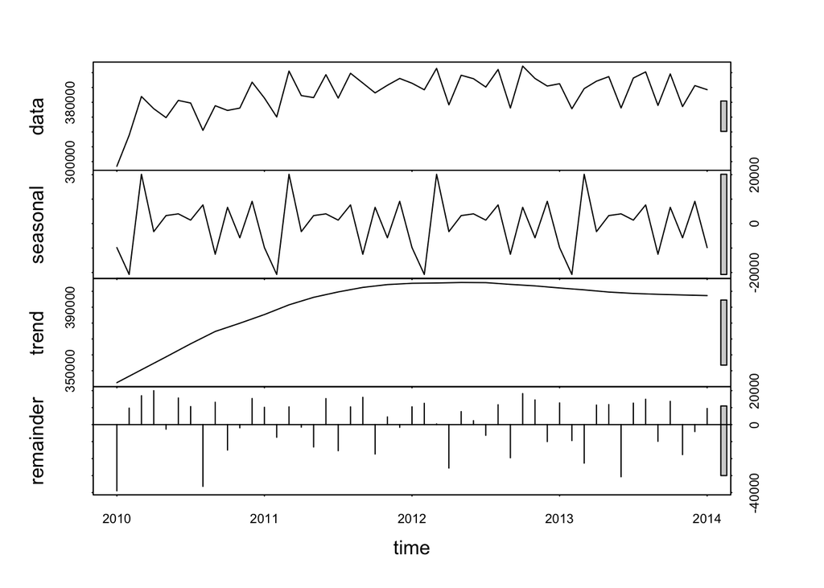

```r
ts_analysis('California')
```

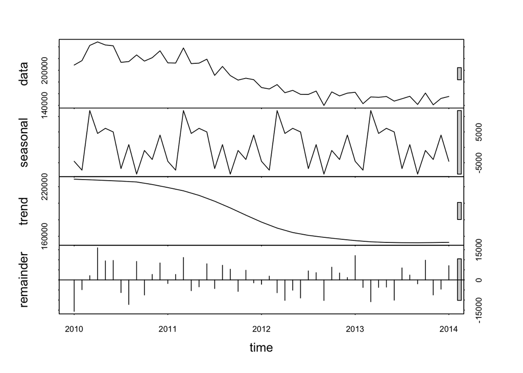

```r
ts_analysis('Florida')
```

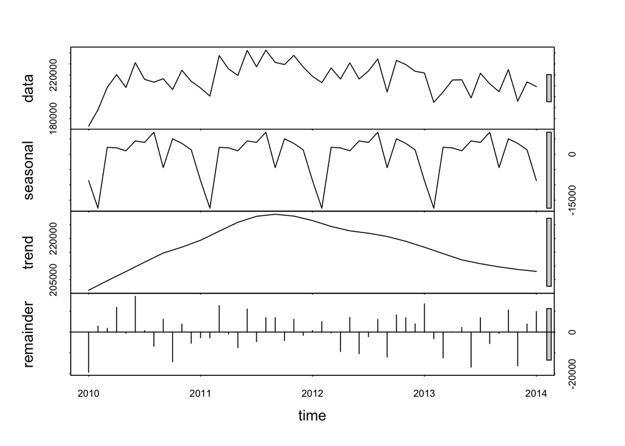

```r
ts_analysis('Tennessee')
```